# descripcionTablas

# Trabajo con los datos de Vicente

## Compuestos fenólicos (Procesado?)

Primero, se mide el efecto de agregar un endulzante determinado al zumo y se van haciendo medidas de metabolitos en diferentes tiempos y condiciones.Tenemos entonces dos factores que determinan el valor de los mg/100 ml de zumo, que serían las condiciones de toma de la muestra y el tipo de endulzante que se está añadiendo.

Medimos cuatro compuestos:

- Derivados del Naringenin hexosido
- Eriodictiol hexosa
- Naringenin rutinosido
- Hespertin rutinosido.

En primer lugar se extrae el área del cromatógrafo y se transforma en mg/100 ml de zumo, con la fórmula siguiente:

$$((AREA-221,08)/18129)*610,19*(0,1)$$

Se repite la medición cada 15 días, en condiciones de luz y oscuridad, a 5º y a 25º celsius de temperatura.

El procesado estadístico realizado en el excel adjuntado consiste en hacer la media y la desviación estándar de cada repetición hecha en las mismas condiciones. Después se calculan los mg totales de compuestos detectados por cada repetición, se hace la media y la SD, además de un porcentaje de pérdida respecto a la primera medida. Se replica en R (faltan los totales y la pérdida)

## Procesado y ordenamiento:

```r
# Funcion de procesado de tablas

procesado <- function(tabla, endulzante){

  tabla_num <- tabla[-1]

  # Se obtienen las medias de cada medida

  tabla_mean <- do.call(rbind,
                        lapply(seq(1, nrow(tabla_num), 2), function(i){
                          x <- tabla_num[ i:(i + 1), , drop = FALSE]
                          res <- rbind(colSums(x)/2)
                          res
                        }))

  rownames(tabla_mean) <- unique(tabla$Condiciones)

  # La desviación estándar

  tabla_sd <- do.call(rbind,
                      lapply(seq(1, nrow(tabla_num), 2), function(i){
                        x <- tabla_num[ i:(i + 1), , drop = FALSE]
                        res <- rbind(apply(x, 2, sd))
                        res
                      }))

  # Apilamos datos

  tabla_1 <- stack(as.data.frame(tabla_mean))
  tabla_1$Condiciones <- rep(unique(tabla$Condiciones),4)

  tabla_2 <- stack(as.data.frame(tabla_sd))
  tabla_2$Condiciones <- rep(unique(tabla$Condiciones),4)

  tabla_total <- merge(tabla_1, tabla_2, by = c("Condiciones", "ind"))

  tabla_total$Endulzante <- rep(endulzante, nrow(tabla_total))

  dplyr::rename(tabla_total, mean = values.x , SD = values.y, Compuesto = ind)

}

# ---- Lectura y procesado de las tablas

fenSU <- read.csv("data/Compuestos fenolicos SU VidaUtil Cronico_1.csv", sep = ";", dec = ",")
fenSA <- read.csv("data/Compuestos fenolicos SA VidaUtil Cronico_1.csv", sep = ";", dec = ",")
fenST <- read.csv("data/Compuestos fenolicos ST VidaUtil Cronico_1.csv", sep = ";", dec = ",")


fenSU_total <- procesado(fenSU, "SU")
fenSA_total <- procesado(fenSA, "SA")
fenST_total <- procesado(fenST, "ST")

fenFlavTotal <- rbind(fenSU_total, fenSA_total, fenST_total)

skimr::skim(fenFlavTotal)
```

Data summary

| Name | fenFlavTotal |
| --- | --- |
| Number of rows | 192 |
| Number of columns | 5 |
| _______________________ |  |
| Column type frequency: |  |
| character | 2 |
| factor | 1 |
| numeric | 2 |
| ________________________ |  |
| Group variables | None |

**Variable type: character**

| skim_variable | n_missing | complete_rate | min | max | empty | n_unique | whitespace |
| --- | --- | --- | --- | --- | --- | --- | --- |
| Condiciones | 0 | 1 | 13 | 24 | 0 | 48 | 0 |
| Endulzante | 0 | 1 | 2 | 2 | 0 | 3 | 0 |

**Variable type: factor**

| skim_variable | n_missing | complete_rate | ordered | n_unique | top_counts |
| --- | --- | --- | --- | --- | --- |
| Compuesto | 0 | 1 | FALSE | 4 | Der: 48, Eri: 48, Nar: 48, Hes: 48 |

**Variable type: numeric**

| skim_variable | n_missing | complete_rate | mean | sd | p0 | p25 | p50 | p75 | p100 | hist |
| --- | --- | --- | --- | --- | --- | --- | --- | --- | --- | --- |
| mean | 0 | 1 | 1.64 | 1.47 | -0.04 | 0.56 | 1.35 | 1.79 | 5.98 | ▆▇▁▂▁ |
| SD | 0 | 1 | 0.03 | 0.07 | 0.00 | 0.00 | 0.00 | 0.01 | 0.57 | ▇▁▁▁▁ |

## Pruebas adicionales

#### Normalidad

```r
shapiro.test(fenFlavTotal$mean)
```

```
##
##  Shapiro-Wilk normality test
##
## data:  fenFlavTotal$mean
## W = 0.85455, p-value = 1.432e-12
```

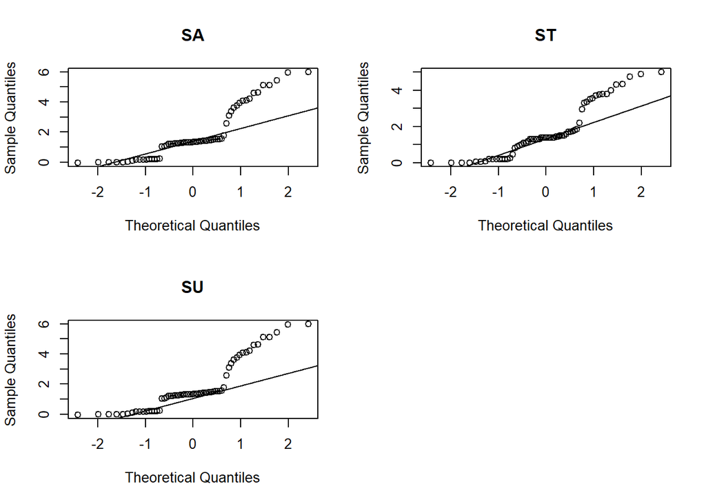

```r
par(mfrow = c(2,2))
qqnorm(fenFlavTotal[fenFlavTotal$Endulzante == "SA","mean"], main = "SA")
qqline(fenFlavTotal[fenFlavTotal$Endulzante == "SA","mean"])
qqnorm(fenFlavTotal[fenFlavTotal$Endulzante == "ST","mean"], main =  "ST")
qqline(fenFlavTotal[fenFlavTotal$Endulzante == "ST","mean"])
qqnorm(fenFlavTotal[fenFlavTotal$Endulzante == "SA","mean"], main = "SU")
qqline(fenFlavTotal[fenFlavTotal$Endulzante == "SU","mean"])
```

La media de las medidas no presenta una distribución normal.

### Homocedasticidad

```r
var.test(x = fenFlavTotal[fenFlavTotal$Endulzante == "SA", "mean"],
         y = fenFlavTotal[fenFlavTotal$Endulzante == "SU", "mean"] )
```

```
##
##  F test to compare two variances
##
## data:  fenFlavTotal[fenFlavTotal$Endulzante == "SA", "mean"] and fenFlavTotal[fenFlavTotal$Endulzante == "SU", "mean"]
## F = 1.4891, num df = 63, denom df = 63, p-value = 0.1167
## alternative hypothesis: true ratio of variances is not equal to 1
## 95 percent confidence interval:
##  0.9046806 2.4511295
## sample estimates:
## ratio of variances
##           1.489124
```

```r
var.test(x = fenFlavTotal[fenFlavTotal$Endulzante == "SA", "mean"],
         y = fenFlavTotal[fenFlavTotal$Endulzante == "ST", "mean"] )
```

```
##
##  F test to compare two variances
##
## data:  fenFlavTotal[fenFlavTotal$Endulzante == "SA", "mean"] and fenFlavTotal[fenFlavTotal$Endulzante == "ST", "mean"]
## F = 1.376, num df = 63, denom df = 63, p-value = 0.208
## alternative hypothesis: true ratio of variances is not equal to 1
## 95 percent confidence interval:
##  0.8359404 2.2648859
## sample estimates:
## ratio of variances
##           1.375976
```

```r
var.test(x = fenFlavTotal[fenFlavTotal$Endulzante == "ST", "mean"],
         y = fenFlavTotal[fenFlavTotal$Endulzante == "SU", "mean"] )
```

```
##
##  F test to compare two variances
##
## data:  fenFlavTotal[fenFlavTotal$Endulzante == "ST", "mean"] and fenFlavTotal[fenFlavTotal$Endulzante == "SU", "mean"]
## F = 1.0822, num df = 63, denom df = 63, p-value = 0.7548
## alternative hypothesis: true ratio of variances is not equal to 1
## 95 percent confidence interval:
##  0.6574828 1.7813753
## sample estimates:
## ratio of variances
##           1.082231
```

Se cumple la condición de homogeneidad de varianzas.

### 2WAY-ANOVA

Dado que comparamos dos variables independientes cualitativas y una variable dependiente cuantitativa, la condición de normalidad no se cumple pero existe cierto margen

#### Box-plot

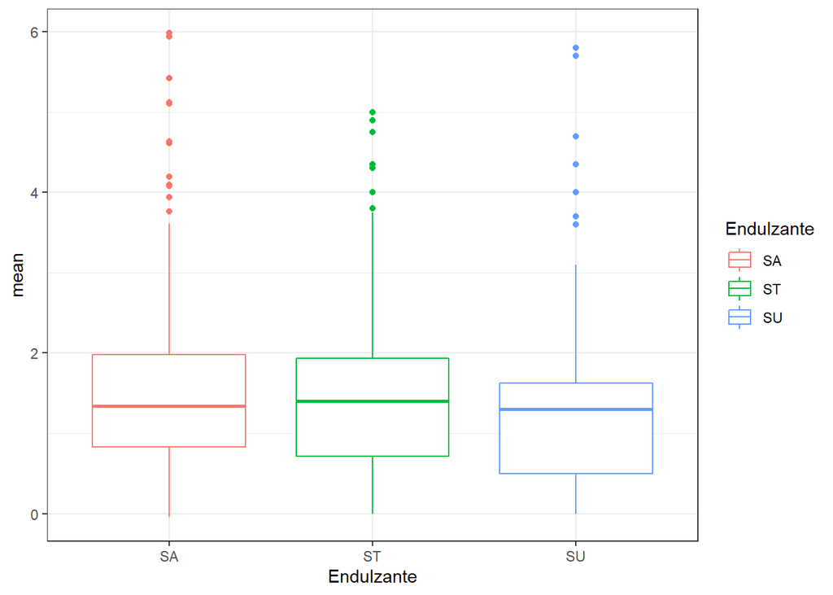

```r
library("ggplot2")
library("gridExtra")

ggplot(data = as.data.frame(fenFlavTotal), aes(x = Endulzante, y = mean, color = Endulzante)) +
  geom_boxplot() +
  theme_bw()
```

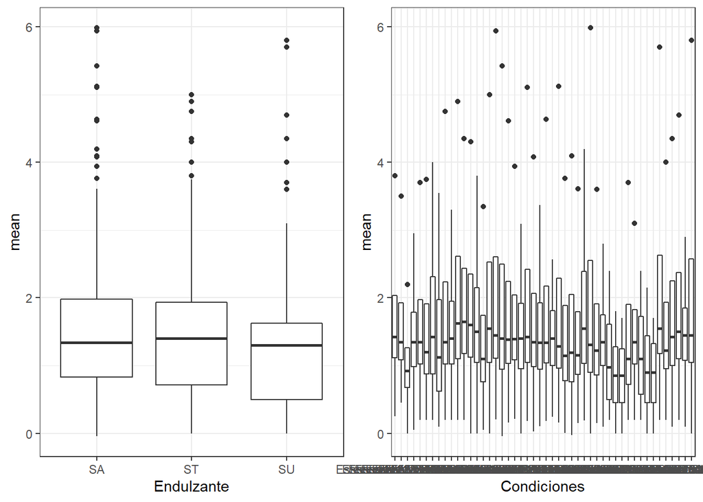

```r
p1 <- ggplot(data = as.data.frame(fenFlavTotal), aes(x = Endulzante, y = mean)) +
  geom_boxplot() + theme_bw()
p2 <- ggplot(data = as.data.frame(fenFlavTotal), aes(x = Condiciones, y = mean)) +
  geom_boxplot() + theme_bw()
p3 <- ggplot(data = as.data.frame(fenFlavTotal), aes(x = Endulzante, y = mean, colour = Condiciones)) +
  geom_boxplot() + theme_bw()

grid.arrange(p1, p2, ncol = 2)
```

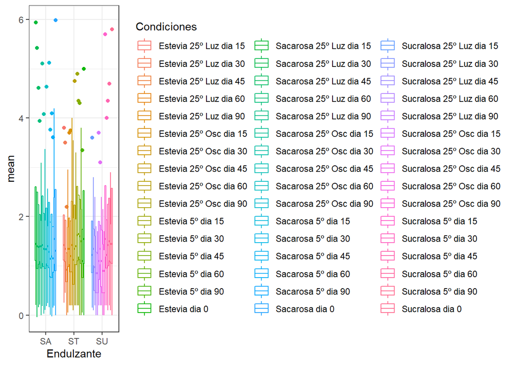

```r
p3
```

### Dudas

Hesperidina?